# Calculate Medians for Dashboard

Author

Judah Axelrod and Aaron R. Williams

Published

January 31, 2024

# Mobility metrics median calculations

This code calculates weighted medians of the mobility metrics at the county and then the place level for the most recent year for each metric.

We want to better understand the quality and availability of county- and place-level metrics that are being aggregated into these national-level medians to determine whether it is appropriate to report at the national level.

We exclude missing values and calculate the proportion of places and proportion of population missing for each metric. The function below is used to calculate the proportion of population missing for each metric.

```r
missing_share <- function(x, weight) {

  sum(as.numeric(is.na(x)) * weight) / sum(weight)

}
```

The steps taken for calculating the median estimates are as follow:

- Calculate the population-weighted median
- Calculate the proportion of places that are missing
- Calculate the proportion of people that are missing

## Load Packages

```r
options(scipen = 999)

library(tidyverse)
library(here)
library(tidycensus)
library(DT)

theme_set(theme_minimal())
```

# County level

## Load Data

```r
metrics <- read_csv(here("data", "00_mobility-metrics_recent.csv")) |>
  select(-ends_with("_lb"), -ends_with("_ub"))

# Create crosswalk for each variable's corresponding quality field
metric_qual_crosswalk <- as_tibble(
  metrics |>
  select((where(is.numeric) & !matches('quality')) | index_air_quality) |>
  colnames()
) |>
  rename(name = value) |>
  mutate(qual_varname = case_when(
    str_detect(name, 'pctl_income') ~ 'pctl_income_quality',
    str_detect(name, 'share_affordable') ~ 'share_affordable_quality',
    str_detect(name, 'homeless') ~ 'homeless_quality',
    str_detect(name, 'crime') ~ 'rate_crime_quality',
    str_detect(name, 'share_desc_rep') ~ NA, # No quality variables for these
    TRUE ~ str_c(name, '_quality')
  ))
```

We load county-level population estimates from the 2020 decennial census.

```r
population <- get_decennial(
  geography = "county",
  variables = "P1_001N",
  year = 2020
) |>
  mutate(
    state = str_sub(GEOID, start = 1, end = 2),
    county = str_sub(GEOID, start = 3, end = 5)
  ) |>
  select(state, county, population = value)

metrics <- left_join(metrics, population, by = c("state", "county"))

# sum(is.na(metrics$population))
```

## Calculate Medians

We calculate weighted medians for each numeric variable. This means our estimates represent the county mobility metric for the average American. We also calculate `share_lq3`, which is the share of the population for which the given metric is either missing or `quality=3`.

```r
weighted_median <- metrics |>
  mutate(county_state = paste0(county_name, ', ', state_name)) |>
  select(county_state, where(is.numeric) & (!ends_with('quality') | index_air_quality)) |>
  summarize(
    across(
      .cols = -c('county_state', 'population'),
      .fns = list(.wtd_med = ~Hmisc::wtd.quantile(., weights = population, probs = 0.5, na.rm = TRUE),
                  .min = ~min(., na.rm=TRUE),
                  .max = ~max(., na.rm=TRUE))
    )
  ) |>
  pivot_longer(cols = everything(),
               names_to = c('.value', 'group'),
               names_pattern = "(.+)_\\.(.+)") |>
  t() |>
  as.data.frame() |>
  rownames_to_column() |>
  tail(-1) |>
  mutate(across(V1:V3, as.numeric)) |>
  rename(name = rowname, weighted_median = V1, min_county = V2, max_county = V3)



state_count <- metrics |>
  pivot_longer(cols = ends_with('_quality') & -index_air_quality, names_to = 'qual_varname', values_to = 'quality') |>
  filter(quality %in% 1:2) |>
  count(state_name, qual_varname) |>
  count(qual_varname, name = 'n_states')

proportion_by_qual <- metrics |>
  select(where(is.numeric)) |>
  pivot_longer(cols = ends_with('_quality') & -index_air_quality, names_to = 'qual_varname', values_to = 'quality') |>
  summarize(population = sum(population),
   .by = c('qual_varname', 'quality')
  ) |>
  mutate(pop_share = population / sum(population), .by = 'qual_varname') |>
  filter(quality %in% 2:3) |>
  select(-population) |>
  arrange(qual_varname, quality)


missing_population <- metrics |>
  select(where(is.numeric) & (!ends_with('quality') | index_air_quality)) |>
  summarize(
    across(
      .cols = -population,
      .fns = ~missing_share(.x, weight = population)
    )) |>
  pivot_longer(cols = everything(), values_to = "missing_population")

missing_county <- metrics |>
  select(where(is.numeric) & (!ends_with('quality') | index_air_quality)) |>
  summarize(
    across(
      .cols = -population,
      .fns = ~sum(is.na(.x)) / n()
    )) |>
  pivot_longer(cols = everything(), values_to = "missing_county")

county_summary <- weighted_median |>
  full_join(missing_population, by = "name") |>
  full_join(missing_county, by = "name") |>
  left_join(metric_qual_crosswalk, by = "name") |>
  left_join(proportion_by_qual, by = "qual_varname") |>  #M:M Merge is expected behavior here
  left_join(state_count, by = "qual_varname") |>
  pivot_wider(names_from = quality, names_glue = 'quality{quality}_popshare', values_from = pop_share) |>
  select(-qual_varname, -qualityNA_popshare) |>
  mutate(across(where(is.numeric), ~round(.,digits=2))) |>
  rowwise() |>
  # Share of pop that is either missing or quality = 3 for that metric
  mutate(share_lq3 = sum(missing_population, quality3_popshare, na.rm = TRUE)) |>
  select(name, share_lq3, everything())

county_summary |>
  relocate(min_county, max_county, .after = last_col()) |>
  datatable()
```

|  | name | share_lq3 | weighted_median | missing_population | missing_county | n_states | quality2_popshare | quality3_popshare | min_county | max_county |
| --- | --- | --- | --- | --- | --- | --- | --- | --- | --- | --- |
| 1 | share_in_preschool | 0.15 | 0.39 | 0 | 0 | 50 | 0.13 | 0.15 | 0.01 | 0.83 |
| 2 | rate_learning | 0.13 | 0.98 | 0.02 | 0.03 | 46 | 0.07 | 0.11 | -1.25 | 2.72 |
| 3 | meps20_black | 0.02 | 0.51 | 0 | 0.03 | 51 | 0.02 | 0.02 | 0 | 1 |
| 4 | meps20_hispanic | 0 | 0.49 | 0 | 0.01 | 51 | 0.01 | 0 | 0 | 1 |
| 5 | meps20_white | 0 | 0.16 | 0 | 0 | 51 | 0 | 0 | 0 | 1 |
| 6 | share_hs_degree | 0.1 | 0.92 | 0 | 0 | 51 | 0.16 | 0.1 | 0.4 | 1 |
| 7 | share_digital_access | 0 | 0.89 | 0 | 0 | 51 | 0 | 0 | 0.23 | 0.99 |
| 8 | pctl_income_20 | 0 | 26340.52 | 0 | 0 | 51 | 0.22 |  | 9117.87 | 73956.08 |
| 9 | pctl_income_50 | 0 | 60785.82 | 0 | 0 | 51 | 0.22 |  | 28164.1 | 163716.5 |
| 10 | pctl_income_80 | 0 | 121571.6 | 0 | 0 | 51 | 0.22 |  | 66053.92 | 324302.5 |

[output cut: 28 more lines]

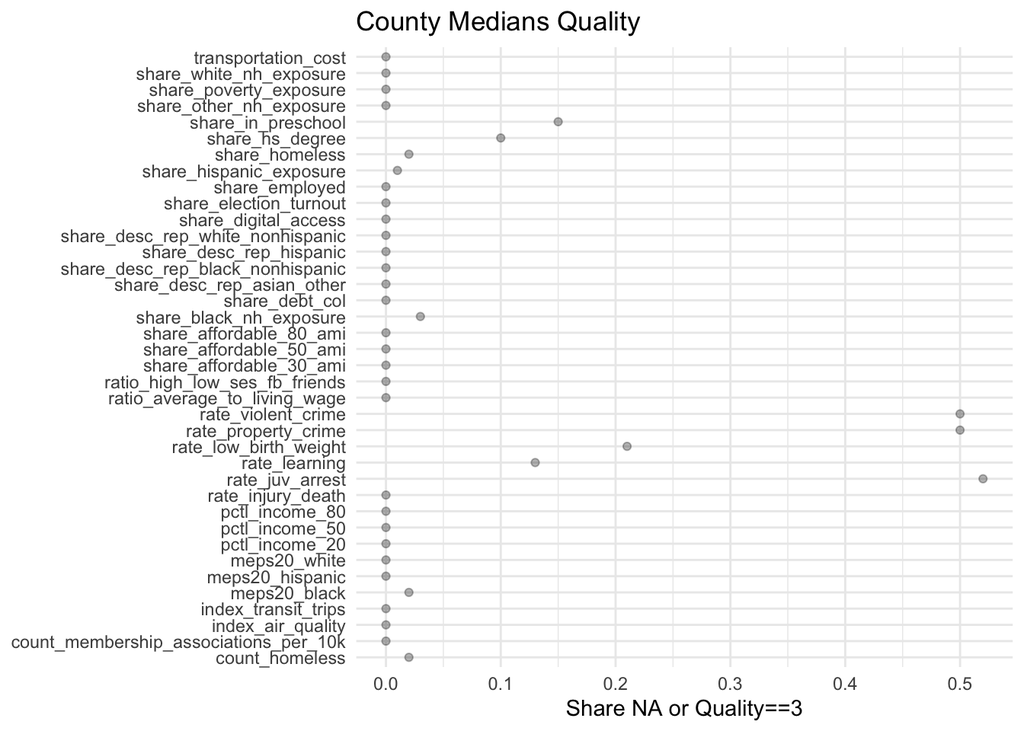

```r
county_summary |>
  ggplot(aes(share_lq3, name)) +
  geom_point(alpha = 0.3) +
  labs(
    title = "County Medians Quality",
    x = "Share NA or Quality==3",
    y = NULL
  )
```

# Place level

This section of the code calculates variable medians at the place level.

## Load Data

```r
metrics <- read_csv(here("data", "05_mobility-metrics_place_recent.csv")) |>
  select(-ends_with("_lb"), -ends_with("_ub"))
```

We load place-level population estimates from the 2020 decennial census.

```r
population <- get_decennial(
  geography = "place",
  variables = "P1_001N",
  year = 2020
) |>
  mutate(
    state = str_sub(GEOID, start = 1, end = 2),
    place = str_sub(GEOID, start = 3, end = 7)
  ) |>
  select(state, place, population = value)

metrics <- left_join(metrics, population, by = c("state", "place"))

sum(is.na(metrics$population))
```

```
[1] 0
```

## Calculate Medians

We calculate the same set of statistics as above for the county-level metrics. This means our estimates represent the place mobility metric for the average American living in a large city.

```r
weighted_median <- metrics |>
  mutate(place_state = paste0(place_name, ', ', state_name)) |>
  select(place_state, where(is.numeric) & (!ends_with('quality') | index_air_quality)) |>
  summarize(
    across(
      .cols = -c('place_state', 'population'),
      .fns = list(.wtd_med = ~Hmisc::wtd.quantile(., weights = population, probs = 0.5, na.rm = TRUE),
                  .min = ~min(., na.rm = TRUE),
                  .max = ~max(., na.rm = TRUE))
    )
  ) |>
  pivot_longer(cols = everything(),
               names_to = c('.value', 'group'),
               names_pattern = "(.+)_\\.(.+)") |>
  t() |>
  as.data.frame() |>
  rownames_to_column() |>
  tail(-1) |>
  mutate(across(V1:V3, as.numeric)) |>
  rename(name = rowname, weighted_median = V1, min_place = V2, max_place = V3)

proportion_by_qual <- metrics |>
  select(where(is.numeric)) |>
  pivot_longer(cols = ends_with('_quality') & -index_air_quality, names_to = 'qual_varname', values_to = 'quality') |>
  summarize(population = sum(population),
   .by = c('qual_varname', 'quality')
  ) |>
  mutate(pop_share = population / sum(population), .by = 'qual_varname') |>
  filter(quality %in% 2:3) |>
  select(-population) |>
  arrange(qual_varname, quality)


state_count <- metrics |>
  pivot_longer(cols = ends_with('_quality') & -index_air_quality, names_to = 'qual_varname', values_to = 'quality') |>
  filter(quality %in% 1:2) |>
  count(state_name, qual_varname) |>
  count(qual_varname, name = 'n_states')

missing_population <- metrics |>
  select(where(is.numeric) & (!ends_with('quality') | index_air_quality)) |>
  summarize(
    across(
      .cols = -population,
      .fns = ~missing_share(.x, weight = population)
    )
  ) |>
  pivot_longer(cols = everything(), values_to = "missing_population")

missing_place <- metrics |>
  select(where(is.numeric) & (!ends_with('quality') | index_air_quality)) |>
  summarize(
    across(
      .cols = -population,
      .fns = ~sum(is.na(.x)) / n()
    )
  ) |>
  pivot_longer(cols = everything(), values_to = "missing_place")

place_summary <- weighted_median |>
  full_join(missing_population, by = "name") |>
  full_join(missing_place, by = "name") |>
  left_join(metric_qual_crosswalk, by = "name") |>
  left_join(state_count, by = "qual_varname") |>
  left_join(proportion_by_qual, by = "qual_varname") |>  #M:M Merge is expected behavior here
  pivot_wider(names_from = quality, names_glue = 'quality{quality}_popshare', values_from = pop_share) |>
  select(-qual_varname, -qualityNA_popshare) |>
  mutate(across(where(is.numeric), ~round(.,digits=2))) |>
  rowwise() |>
  # Share of pop that is either missing or quality = 3 for that metric
  mutate(share_lq3 = sum(missing_population, quality3_popshare, na.rm = TRUE)) |>
  select(name, share_lq3, everything())

place_summary |>
  relocate(min_place, max_place, .after = last_col()) |>
  datatable()
```

|  | name | share_lq3 | weighted_median | missing_population | missing_place | n_states | quality2_popshare | quality3_popshare | min_place | max_place |
| --- | --- | --- | --- | --- | --- | --- | --- | --- | --- | --- |
| 1 | share_in_preschool | 0.07 | 0.4 | 0 | 0 | 45 | 0.25 | 0.07 | 0.05 | 0.86 |
| 2 | rate_learning | 0.25 | 1 | 0.2 | 0.18 | 40 | 0.09 | 0.05 | 0.29 | 1.54 |
| 3 | meps20_black | 0.01 | 0.65 | 0.01 | 0.01 | 45 |  | 0 | 0 | 1 |
| 4 | meps20_hispanic | 0.01 | 0.66 | 0.01 | 0.01 | 45 | 0 |  | 0 | 1 |
| 5 | meps20_white | 0.01 | 0.21 | 0.01 | 0.01 | 45 |  |  | 0 | 1 |
| 6 | share_hs_degree | 0.05 | 0.91 | 0 | 0 | 46 | 0.26 | 0.05 | 0.53 | 1 |
| 7 | share_digital_access | 0 | 0.88 | 0 | 0 | 46 |  |  | 0.66 | 0.98 |
| 8 | pctl_income_20 | 0.01 | 25748.2 | 0 | 0 | 46 | 0.28 | 0.01 | 12359.14 | 85484.02 |
| 9 | pctl_income_50 | 0.01 | 67975.25 | 0 | 0 | 46 | 0.28 | 0.01 | 36047.48 | 185387.04 |
| 10 | pctl_income_80 | 0.01 | 139040.28 | 0 | 0 | 46 | 0.28 | 0.01 | 72094.96 | 424742.31 |

[output cut: 23 more lines]

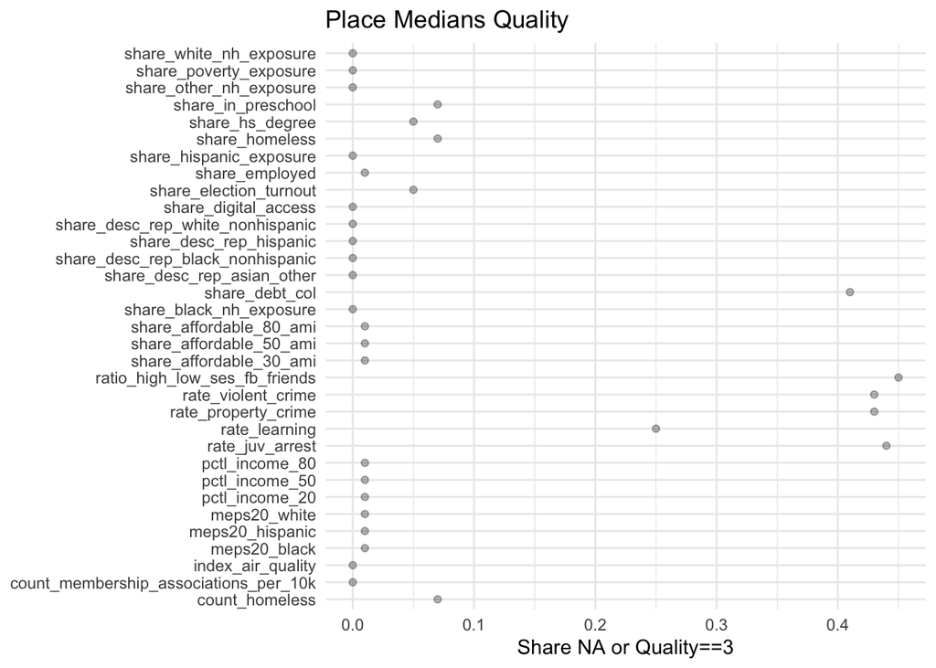

```r
place_summary |>
  ggplot(aes(share_lq3, name)) +
  geom_point(alpha = 0.3) +
  labs(
    title = "Place Medians Quality",
    x = "Share NA or Quality==3",
    y = NULL
  )
```

# Discussion

- `share_in_preschool`
- `rate_learning`
- `share_hs_degree`
- `rate_low_birthweight`
- `rate_violent_crime`
- `rate_property_crime`
- `rate_juv_arrest`
- `ratio_high_low_ses_fb_friends`
- `share_debt_col`

## Debt collection in more detail:

There is a high share of debt in collections missing at place level in the final data set.

```
[1] 382
```

The distribution of population for places missing the debt in collections variable is skewed to the right where the missing distribution for juvenile arrests closely reflects the general population distribution.

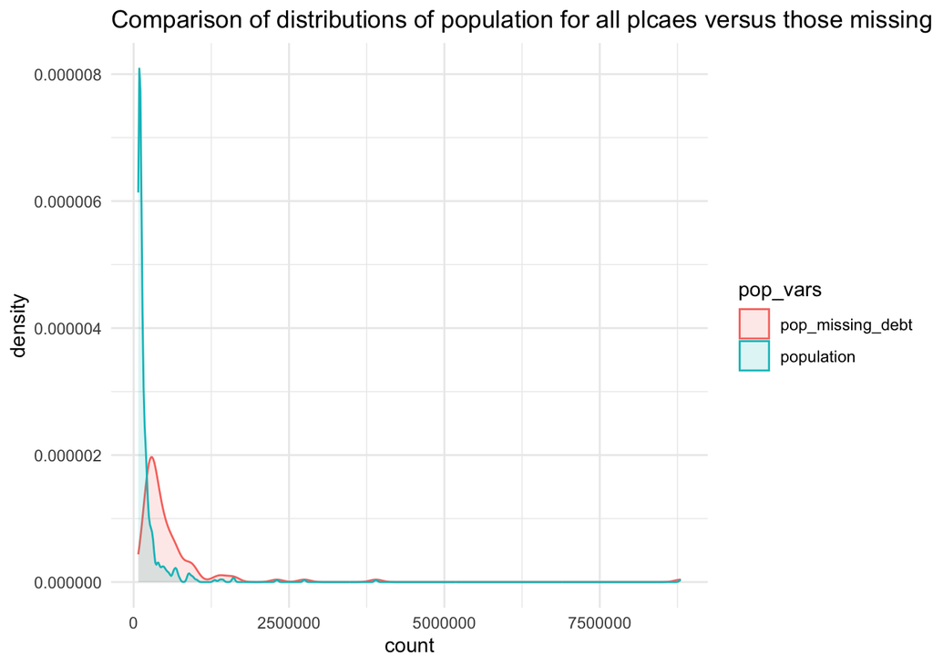

```r
#| echo: false
metrics %>%
  mutate(
    pop_missing_debt = ifelse(is.na(share_debt_col), NA_integer_, population),
    pop_missing_juv = ifelse(is.na(rate_juv_arrest), NA_integer_, population)
  ) %>%
  select(place_name, population, pop_missing_debt) %>%
  pivot_longer(-place_name, names_to = "pop_vars", values_to = "count") %>%
  ggplot(aes(x = count, color = pop_vars, fill = pop_vars)) +
  geom_density(alpha = 0.15) +
  theme_minimal() +
  ggtitle(
    "Comparison of distributions of population for all plcaes versus those missing share of debt in collections"
  )
```

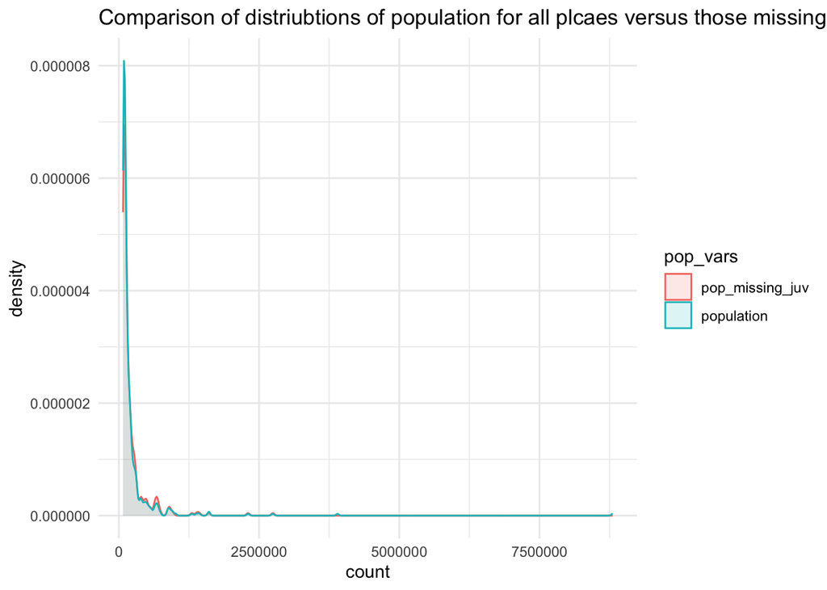

```r
metrics %>%
  mutate(
    pop_missing_debt = ifelse(is.na(share_debt_col), NA_integer_, population),
    pop_missing_juv = ifelse(is.na(rate_juv_arrest), NA_integer_, population)
  ) %>%
  select(place_name, population, pop_missing_juv) %>%
  pivot_longer(-place_name, names_to = "pop_vars", values_to = "count") %>%
  ggplot(aes(x = count, color = pop_vars, fill = pop_vars)) +
  geom_density(alpha = 0.15) +
  theme_minimal() +
  ggtitle(
    "Comparison of distriubtions of population for all plcaes versus those missing rate_juv_arrest"
  )
```